# Test

###### 7번 문제의 결과인 data.frame변수를 이용하여 직업별 월급의 차이가 나는지 분석하고, 만약 월급의 차이가 나면 어떤 직업이 월급이 가장 많은지 상위 10개 직업군만 시각화하시오.

```r
code_welfare <- read_xlsx('D:/bigData/Download/sharedBigdata/Koweps/Koweps_Codebook.xlsx', sheet=2)
fit2 <- lm(income~code_job, data = welfare)
anova(fit2) # F값 0.05미만
```

```
## Analysis of Variance Table
##
## Response: income
##             Df    Sum Sq  Mean Sq F value    Pr(>F)
## code_job     1  16761463 16761463   571.8 < 2.2e-16 ***
## Residuals 4619 135399922    29314
## ---
## Signif. codes:  0 '***' 0.001 '**' 0.01 '*' 0.05 '.' 0.1 ' ' 1
```

```r
job_income <- welfare %>%
  filter(!is.na(welfare$income)) %>%
  group_by(code_job) %>%
  summarise(income.mean = mean(income),
            income.sd   = sd(income))
View(job_income)
job10 <- head(job_income[order(-job_income$income.mean), ],10)
job10
```

```
## # A tibble: 10 x 3
##    code_job income.mean income.sd
##       <dbl>       <dbl>     <dbl>
##  1      233        845.     874.
##  2      241        844.     591.
##  3      111        750      707.
##  4      132        726.     301.
##  5      742        572.      98.9
##  6      120        564.     393.
##  7      134        557.     421.
##  8      131        550.     141.
##  9      141        536.     320.
## 10      831        532.     336.
```

```r
head(code_welfare)
```

```
## # A tibble: 6 x 2
##   code_job job
##      <dbl> <chr>
## 1      111 의회의원 고위공무원 및 공공단체임원
## 2      112 기업고위임원
## 3      120 행정 및 경영지원 관리자
## 4      131 연구 교육 및 법률 관련 관리자
## 5      132 보험 및 금융 관리자
## 6      133 보건 및 사회복지 관련 관리자
```

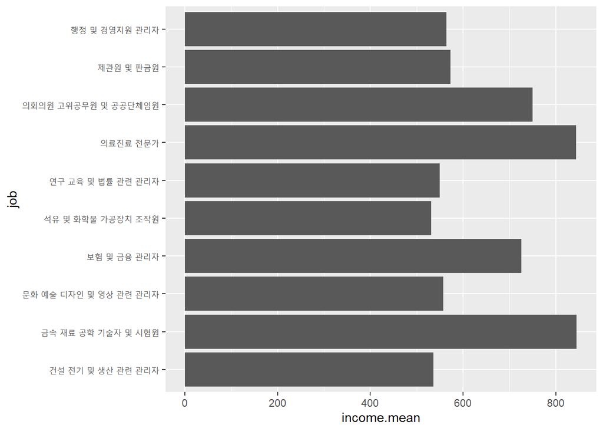

```r
job10 <- left_join(job10, code_welfare[, c('code_job','job')], by='code_job')
ggplot(job10, aes(x=income.mean, y=job)) +
  geom_col()
```

#### 8번. 1번 문제의 결과인 data.frame변수를 이용하여 성별로 어떤 직업이 가장 많을지 분석하시오.

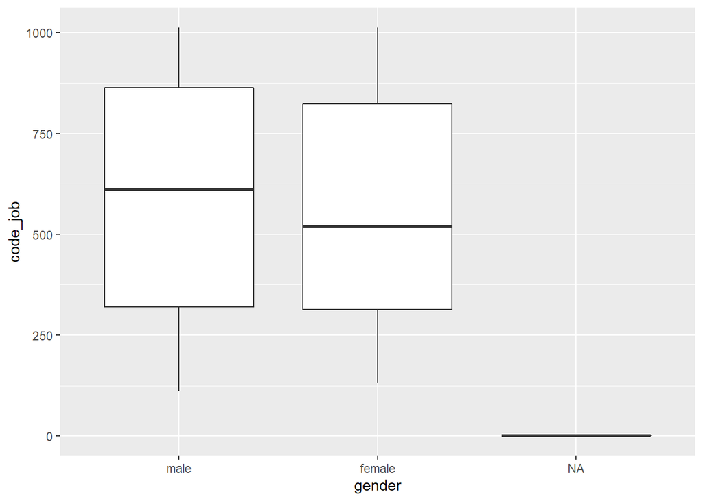

```r
welfare2 <- left_join(welfare, code_welfare[, c('code_job','job')], by='code_job')
ggplot(welfare, aes(x=gender, y=code_job)) +
  geom_boxplot()
```

#### 9번. 1번 문제의 결과인 data.frame변수를 이용하여 종교 유무에 따른 이혼률을 분석하시오.

```r
table(is.na(welfare$religion)) # 결측치 없음
```

```
##
## FALSE
## 16665
```

```r
welfare$religion <- ifelse(welfare$religion==1, "종교-유","종교-무")
table(welfare$religion)
```

```
##
## 종교-무 종교-유
##    8617    8048
```

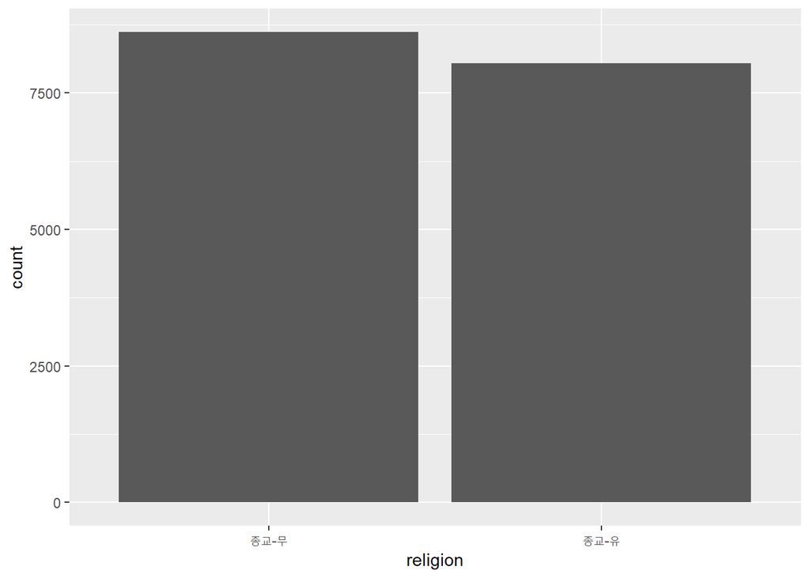

```r
ggplot(welfare, aes(x=religion)) +
  geom_bar()
```

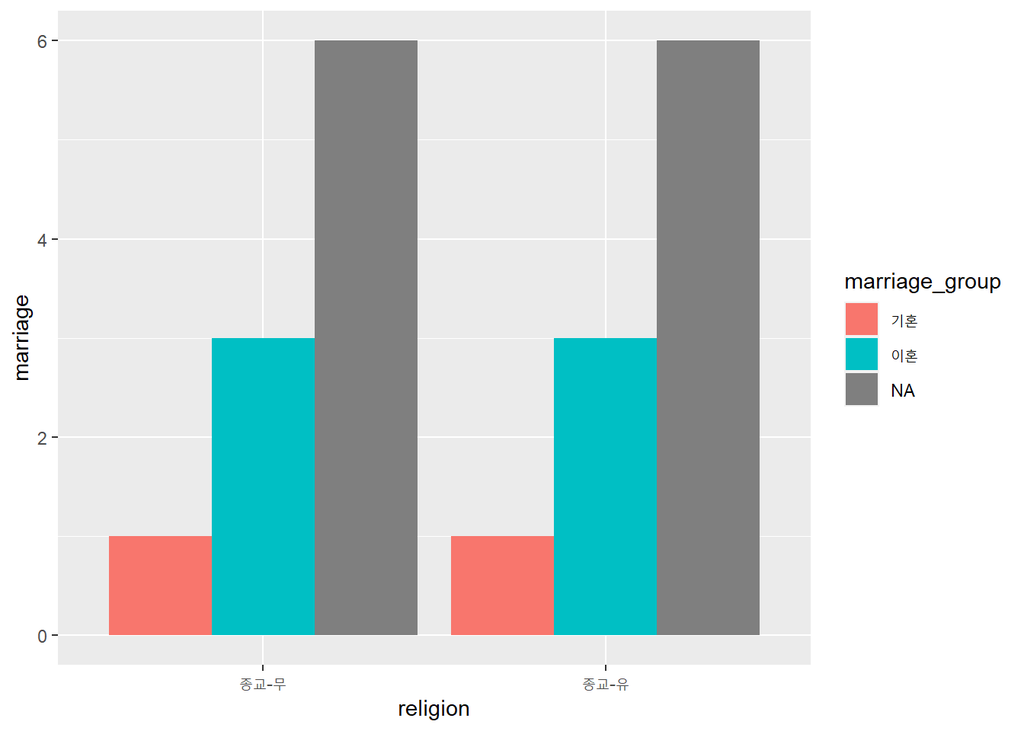

```r
marriage_group <- ifelse(welfare$marriage==1, "기혼",
                         ifelse(welfare$marriage==3, "이혼", NA))
ggplot(welfare, aes(x=religion, y=marriage, fill=marriage_group)) +
  geom_col(position = 'dodge')
```

#### 10번. 1번 문제의 결과인 data.frame변수를 이용하여 지역별 연령대 비율을 분석하시오.

#### 노년층이 많은 지역은 어디인지 출력하시오.

```r
library(ggplot2)
welfare2 <- welfare
region_group <- ifelse(welfare$code_region==1,"서울",
                         ifelse(welfare$code_region==2, "수도권(인천/경기)",
                                ifelse(welfare$code_region==3, "부산/경남/울산",
                                       ifelse(welfare$code_region==4, "대구/경북",
                                              ifelse(welfare$code_region==5, "대전/충남",
                                                     ifelse(welfare$code_region==6, "강원/충북",
                                                            ifelse(welfare$code_region==7, "광주/전남/전북/제주도",NA)))))))
welfare2 <- cbind(welfare2, region_group)
head(welfare2)
```

```
##   gender birth marriage religion code_job income code_region age agegrade
## 1 female  1936        2  종교-무       NA     NA           1  80      old
## 2 female  1945        2  종교-무       NA     NA           1  71      old
## 3   male  1948        2  종교-무      942    120           1  68      old
## 4   male  1942        3  종교-유      762    200           1  74      old
## 5 female  1923        2  종교-유       NA     NA           1  93      old
## 6   male  1962        1  종교-유      530     NA           1  54   middle
##   region_group
## 1         서울
## 2         서울
## 3         서울
## 4         서울
## 5         서울
## 6         서울
```

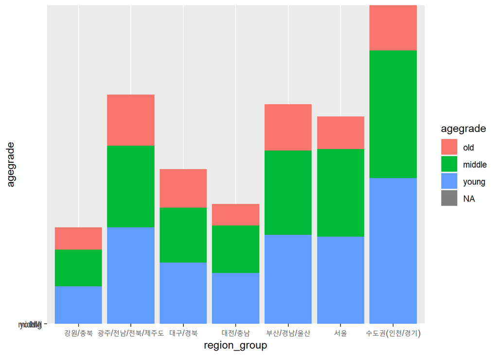

```r
ggplot(welfare, aes(x=region_group, y=agegrade, fill=agegrade)) +
  geom_col()
```

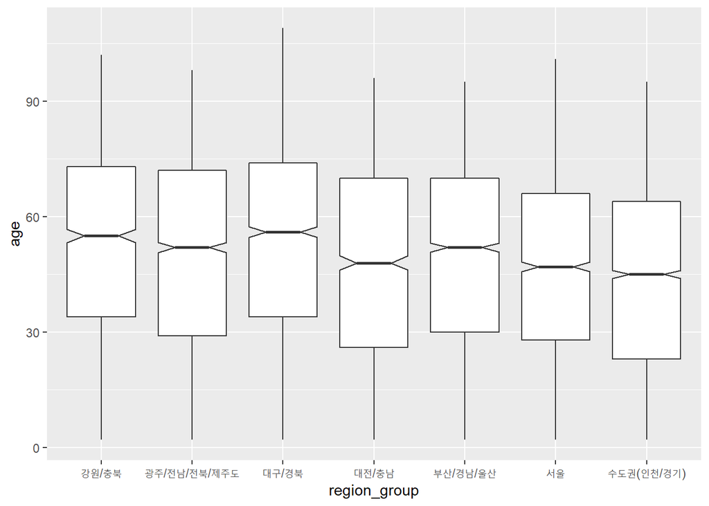

```r
ggplot(welfare, aes(x=region_group, y=age)) +
  geom_boxplot(notch=TRUE)
```